# Proyecto M1

## About the series

## Setup

```
# A tsibble: 441 x 5 [1M]
# Key:       State, Industry [1]
   State           Industry                  `Series ID`    Month Turnover
   <chr>           <chr>                     <chr>          <mth>    <dbl>
 1 New South Wales Household goods retailing A3349397X   1982 Apr     211.
 2 New South Wales Household goods retailing A3349397X   1982 May     224.
 3 New South Wales Household goods retailing A3349397X   1982 Jun     216.
 4 New South Wales Household goods retailing A3349397X   1982 Jul     226.
 5 New South Wales Household goods retailing A3349397X   1982 Aug     217.
 6 New South Wales Household goods retailing A3349397X   1982 Sep     213.
 7 New South Wales Household goods retailing A3349397X   1982 Oct     224.
 8 New South Wales Household goods retailing A3349397X   1982 Nov     244.
 9 New South Wales Household goods retailing A3349397X   1982 Dec     393.
10 New South Wales Household goods retailing A3349397X   1983 Jan     220.
# ℹ 431 more rows
```

```
# A tsibble: 6 x 5 [1M]
# Key:       State, Industry [1]
  State           Industry                  `Series ID`    Month Turnover
  <chr>           <chr>                     <chr>          <mth>    <dbl>
1 New South Wales Household goods retailing A3349397X   2018 Jul    1420.
2 New South Wales Household goods retailing A3349397X   2018 Aug    1427
3 New South Wales Household goods retailing A3349397X   2018 Sep    1419.
4 New South Wales Household goods retailing A3349397X   2018 Oct    1502.
5 New South Wales Household goods retailing A3349397X   2018 Nov    1624.
6 New South Wales Household goods retailing A3349397X   2018 Dec    1839.
```

## Plot of turnover

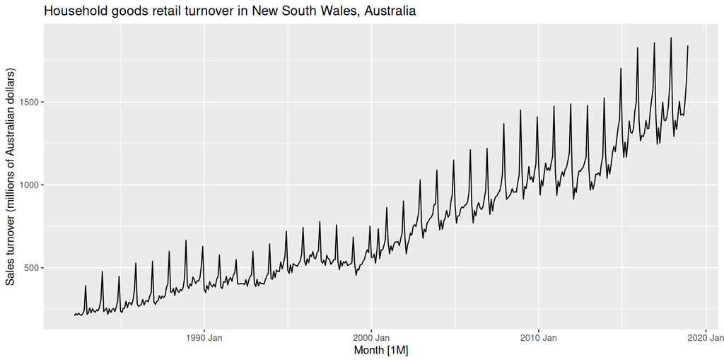

We can notice three things about the series:

1. An upward trend.
2. A peak every year. Reading the data, it seems to be on December. It might have seasonality.
3. The size of the seasonal swings increases as time goes by. That means the series is heteroskedastic.

## Seasonal plot

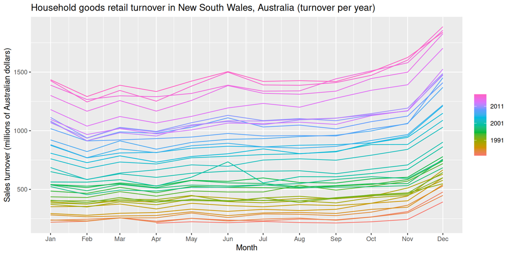

This plot confirms not only that our series has yearly seasonality with a peak on December, it also reveals a minor peak on June (this could be due to accounting years in Australia customarily ending in June, which leads to seasonal purchases).

## Subseries

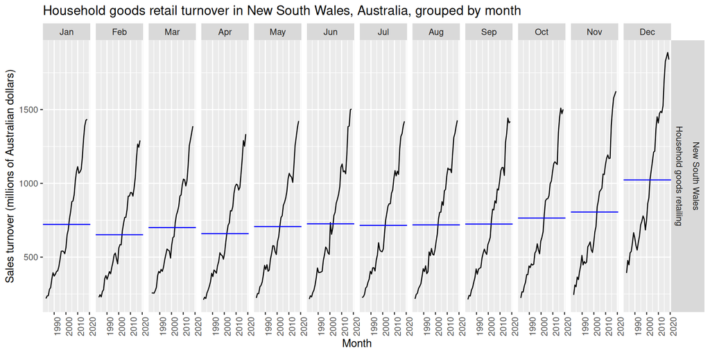

This plot shows that December is the month with the highest average. December is also the month that rises more steeply than the other months. That means the series is **heteroskedastic** (the seasonal effect scales with magnitude [multiplicative seasonality], making the series’s variance non-constant).

## Autocorrelation

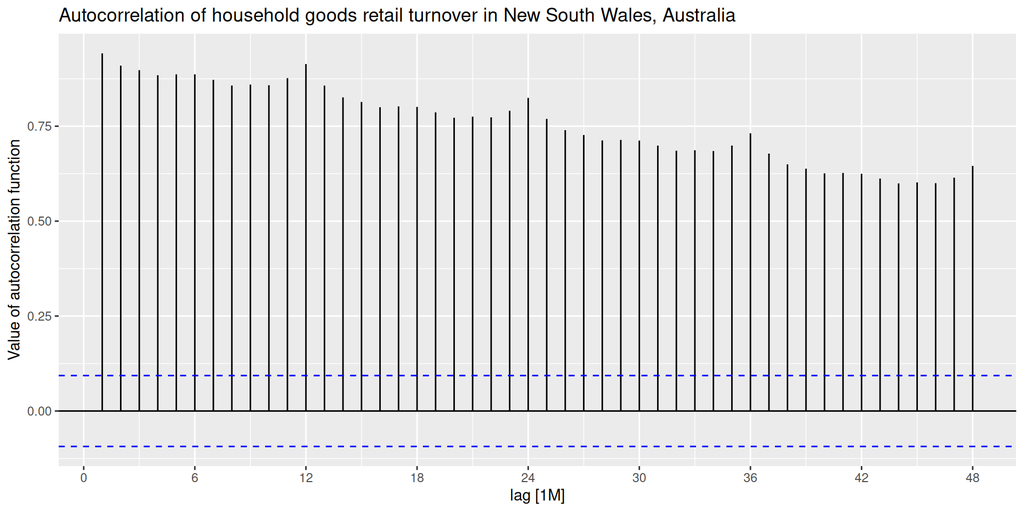

We can see in this autocorrelation function (ACF) plot that **the series has a trend** (the ACF decreases slowly) and that **the series is seasonal and repeats every 12 months** (the ACF peaks every 12 months).

## Result of EDA

- The series **has a trend** (increasing as shown from the time-domain plot and the ACF).
- The series **is seasonal yearly** (the autocorrelation function peaks every 12 time units [months], the subseries plot shows December as notoriously higher, the seasonal plot shows clear peaks in June and December).
- The series **shows a minor seasonal peak on June**.
- The series is **heteroskedastic** (the seasonal peaks have an increasing amplitude as time goes by, shown in the time-domain plot as well as the subseries plot).

## Box-Cox transform

We start by calculating our optimal lambda

## Box-Cox transform

Since we calculated our lambda via Guerrero method, we can see how this lambda will be the best one that stabilizes the amplitude of the seasonal peaks:

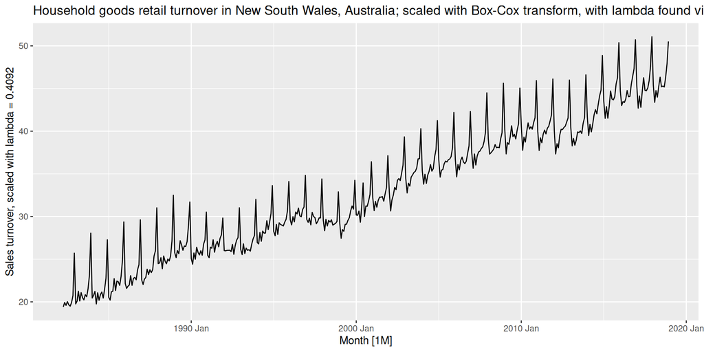

## Box-Cox transform

If we return to our vanilla series, we can notice how the vanilla series has a more exponential growth and how the amplitude of its seasonal peaks increases more as time goes by.

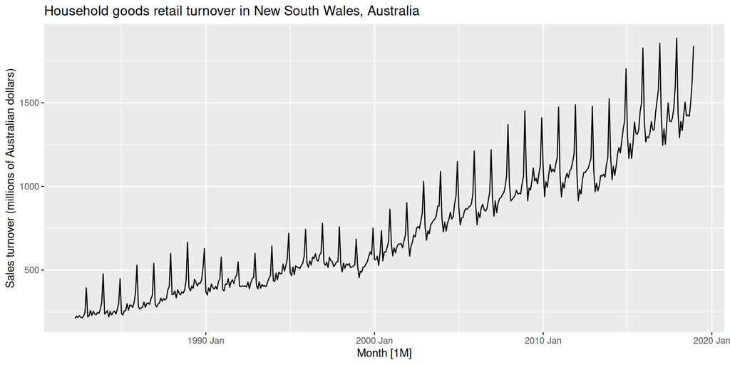

## STL

STL splits the series additively into trend, seasonality and remainder.

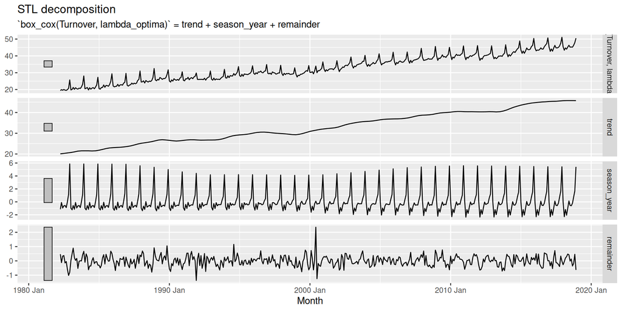

## Data exploration

The remainder shows a large peak in June 2000. What happened? This peak flags an anomaly, something that happened, because the remainder means patterns that cannot be explained as a result of trend or seasonality. From the remainder chart, we can tell the peak’s amplitude is higher than 2; so we can find when it happened by filtering entries of the STL decomposition whose remainder is larger than 2.

We can also see a large dip in sales following that spike, which shows in the remainder chart as having an amplitude lower than -1. Therefore, we search for it too.

```
# A dable: 1 x 9 [1M]
# Key:     State, Industry, .model [1]
# :        box_cox(Turnover, lambda_optima) = trend + season_year + remainder
  State        Industry .model    Month box_cox(Turnover, la…¹ trend season_year
  <chr>        <chr>    <chr>     <mth>                  <dbl> <dbl>       <dbl>
1 New South W… Househo… espec… 2000 Jun                   33.9  31.5       0.103
# ℹ abbreviated name: ¹`box_cox(Turnover, lambda_optima)`
# ℹ 2 more variables: remainder <dbl>, season_adjust <dbl>
```

```
# A dable: 3 x 9 [1M]
# Key:     State, Industry, .model [1]
# :        box_cox(Turnover, lambda_optima) = trend + season_year + remainder
  State        Industry .model    Month box_cox(Turnover, la…¹ trend season_year
  <chr>        <chr>    <chr>     <mth>                  <dbl> <dbl>       <dbl>
1 New South W… Househo… espec… 1982 Nov                   20.7  20.6       1.17
2 New South W… Househo… espec… 1991 Dec                   29.8  26.8       4.41
3 New South W… Househo… espec… 2000 Jul                   30.0  31.6      -0.344
# ℹ abbreviated name: ¹`box_cox(Turnover, lambda_optima)`
# ℹ 2 more variables: remainder <dbl>, season_adjust <dbl>
```

The peak happened in June 2000. We already know June is the end of fiscal year in Australia. Therefore, what happened on July 2000 that is related to taxation norms?

A quick search turns up [an article from four professors of the Australia National University](https://press-files.anu.edu.au/downloads/press/p92201/pdf/article02.pdf), which says a major tax package went into effect in July 2000, which levied a 10% tax on most goods and services similar to Mexico’s VAT (IVA), prompting a large peak in purchases before the tax was enacted followed by a large dip in purchases on July, which happened because many purchases that people planned to do on July were made in June.

This little exercise shows how STL analysis can be used for data exploration.